# Part_II_slide_deck_template

```python
# import all packages and set plots to be embedded inline
!pip install geopy
import numpy as np
import pandas as pd
import matplotlib.pyplot as plt
import seaborn as sb
from glob import glob
from geopy.geocoders import Nominatim
from IPython.display import display, Markdown
import cv2
import warnings
warnings.simplefilter("ignore")
%matplotlib inline
import cv2
```

```python
def disp(text):
    display(Markdown(text))
```

```python
def plot_img(file, title):
    img = cv2.imread(file)
    img = cv2.cvtColor(img, cv2.COLOR_BGR2RGB)
    plt.figure(figsize=(15,15))
    plt.title(title)
    plt.xlabel("East-West")
    plt.ylabel("South-North")
    plt.xlabel("East-West")
    plt.xticks([])
    plt.yticks([])
    plt.imshow(img)
    plt.show()
```

```python
global_sample = False # If True it will display a sample of the data for program syntax testing. If False will work with the whole dataframe
def bar_graph_single_feature (df, feature, suptitle, x_label, xticks = "", color_palette =4, sample=False):
    base_color = sb.color_palette()[color_palette]
    graph = sb.catplot(data = (df if sample == False else df.sample(n=100)), x = feature, kind = 'count', aspect = 1.7, color = base_color);

    graph.set_axis_labels(x_label, 'Number of Bike Trips'),

    graph.fig.suptitle(suptitle, y = 1.05, fontsize = 16, fontweight = 'bold')

    if (xticks!= ''):
        graph.set_xticklabels(xticks, rotation=75)
```

```python
def graph_stations_correlation(df, title):
    stations_correlation = df.groupby(['start_station_name', 'end_station_name']).size().reset_index(name='count')
    stations_correlation_heatmap_pivotdata = stations_correlation.pivot(index='start_station_name', columns='end_station_name', values='count')
    '''Let's see the values first'''
    stations_correlation.describe()
    f, ax = plt.subplots(figsize=(15, 15))

    #plt.title(title, loc='left', fontsize=20, weight='bold');
    sb.heatmap(stations_correlation_heatmap_pivotdata, cmap ='Blues', linewidths = 0.30)
    ax.invert_yaxis()
    plt.xlabel('End Station', fontsize = 15) # x-axis label with fontsize 15
    plt.ylabel('Start Station', fontsize = 15) # y-axis label with fontsize 15
```

# Part II - Visualizing FordGoBike Data

## by: Khaled Zoheir

## Investigation Overview

> Bay Wheels is a regional public bicycle sharing system in California's San Francisco Bay Area. It is operated by Motivate in a partnership with the Metropolitan Transportation Commission and the Bay Area Air Quality Management District.

> In June 2017 the system was officially re-launched as Ford GoBike in a partnership with Ford Motor Company. After Motivate's acquisition by Lyft, the system was renamed to Bay Wheels in June 2019. The system is expected to expand to 7,000 bicycles around 540 stations in San Francisco, Oakland, Berkeley, Emeryville, and San Jose.

let's see where those 5 cities are on the map this was - as well as the station distribution

[figure not shown]

```python
disp("### let's see where those 5 cities are on the map this was - as well as the station distribution")
plot_img('5_cities_bike_sharing_sanFrancisco.png', '5_cities_bike_sharing_sanFrancisco')
```

> Two differnet perspectives (pupose) of the analysis:Business Perspective: Our main customers are the Subscibers

> Operation Perspective: We need to provide the best possible service and have the bikes available when and where needed.
> - For this we can see that we need to send more bikes to the following station: `San Francisco Caltrain (Townsend St at 4th St)` in the morning during weekdays
> - Those bikes can mainly come from the following station: `Montgomery St BART Station (Market St at 2nd St)`
> - This is just an aexample on how can we support the operation. similar analysis needs to be done for other areas as well

## Dataset Overview

> Udacity provided a link to the dataset. After some work, I found this was for one month only (Feb). Looked at knowledge base: https://knowledge.udacity.com/questions/668930 and them got the files from: https://s3.amazonaws.com/baywheels-data/index.html. This is slightly different dataset with some of the features are missing and others are present

```python
# load in the dataset into a pandas dataframe
df_bike_trips = pd.read_csv('master_bikes_dataset.csv')
print(len(df_bike_trips))
```

```
2426322
```

```python
df_bike_trips.info()
```

```
<class 'pandas.core.frame.DataFrame'>
RangeIndex: 2426322 entries, 0 to 2426321
Data columns (total 27 columns):
 #   Column                   Dtype
---  ------                   -----
 0   start_time               object
 1   end_time                 object
 2   start_station_id         float64
 3   start_station_name       object
 4   start_station_latitude   float64
 5   start_station_longitude  float64
 6   end_station_id           float64
 7   end_station_name         object
 8   end_station_latitude     float64
 9   end_station_longitude    float64
```

[output cut: 19 more lines]

> Note that the above cells have been set as "Skip"-type slides. That means that when the notebook is rendered as http slides, those cells won't show up.

```python
df_bike_trips.dropna(subset=['start_station_id' , 'start_station_name', 'end_station_id', 'end_station_name'], inplace=True)
df_bike_trips['start_time'] = pd.to_datetime(df_bike_trips['start_time'])
df_bike_trips['end_time'] = pd.to_datetime(df_bike_trips['end_time'])

df_bike_trips['start_station_id'] = df_bike_trips['start_station_id'].astype('str')
df_bike_trips['end_station_id'] = df_bike_trips['end_station_id'].astype('str')
df_bike_trips['bike_id'] = df_bike_trips['bike_id'].astype('str')

df_bike_trips['user_type'] = df_bike_trips['user_type'].astype('category')
df_bike_trips['rental_access_method'] = df_bike_trips['rental_access_method'].astype('category')

df_bike_trips['day_of_the_year'] = df_bike_trips['day_of_the_year'].astype('category')
df_bike_trips['day_of_week'] = df_bike_trips['day_of_week'].astype('category')
df_bike_trips['month'] = df_bike_trips['month'].astype('category')
df_bike_trips.info()
```

```
<class 'pandas.core.frame.DataFrame'>
Int64Index: 2426322 entries, 0 to 2426321
Data columns (total 27 columns):
 #   Column                   Dtype
---  ------                   -----
 0   start_time               datetime64[ns]
 1   end_time                 datetime64[ns]
 2   start_station_id         object
 3   start_station_name       object
 4   start_station_latitude   float64
 5   start_station_longitude  float64
 6   end_station_id           object
 7   end_station_name         object
 8   end_station_latitude     float64
 9   end_station_longitude    float64
```

[output cut: 19 more lines]

```python
months = ['January', 'February', 'March', 'April', 'May', 'June', 'July', 'August', 'September', 'October', 'November', 'December']
week_day = ['Mon', 'Tue', 'Wed', 'Thu', 'Fri', 'Sat', 'Sun']
```

Let's take a look at the utilization distribution over the 12 months

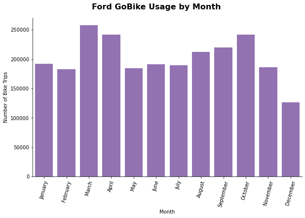

```python
disp("### Let's take a look at the utilization distribution over the 12 months")

bar_graph_single_feature (df_bike_trips, 'month', 'Ford GoBike Usage by Month', 'Month', months, sample=global_sample)
```

```python
disp("### Surprisingly! The summer is not the highest utilization. May be it's too hot for biking.")
disp("### The highst months are spring and autumn months. Not too cold and not too hot apparently")
```

Surprisingly! The summer is not the highest utilization. May be it's too hot for biking.

The highst months are spring and autumn months. Not too cold and not too hot apparently

Now, let's look at the peak hours in a typical working day: Mon-Fri

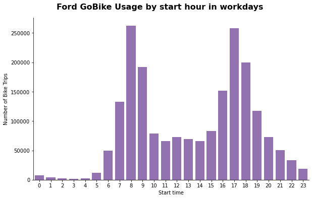

```python
disp("### Now, let's look at the peak hours in a typical working day: Mon-Fri")
bar_graph_single_feature (df_bike_trips[df_bike_trips.working_day == True], feature='hour_of_day', suptitle='Ford GoBike Usage by start hour in workdays', x_label='Start time', xticks='', sample=False)
```

```python
disp("#### As expected, two peaks: 7:00 - 9:00 am and 4:00 - 7:00 pm.  We can easily conclude that many are using it to go to work.")
disp("#### In the analysis we confirmed this finding by looking including the weekends as well")
```

As expected, two peaks: 7:00 - 9:00 am and 4:00 - 7:00 pm. We can easily conclude that many are using it to go to work.

In the analysis we confirmed this finding by looking including the weekends as well

Who are our main users? There are two types of users: Subscribers and customers

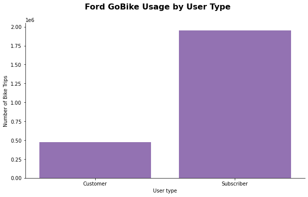

```python
disp("### Who are our main users? There are two types of users: Subscribers and customers")
bar_graph_single_feature (df_bike_trips, feature='user_type', suptitle='Ford GoBike Usage by User Type', x_label='User type', xticks='', sample=False)
```

```python
disp("### By far our main users are the Subscribers.")
disp("#### May be we should take care of them more,")
disp("#### Or may be we can increase the numver of Customers")
```

By far our main users are the Subscribers.

May be we should take care of them more,

Or may be we can increase the numver of Customers

```python
disp("### What are the busiest stations and where are they located?")
df_tmp = df_bike_trips['start_station_name'].value_counts().nlargest(6).reset_index()
most_frequent_stations= list(df_tmp.iloc[:,0])
for i in most_frequent_stations:
    st = "#### * " + i
    disp(st)
#disp("### We will rename them to shorter names for the heatmap below")
short_stations_names = {
    'San Francisco Caltrain (Townsend St at 4th St)': 'SF Caltrain',
    'San Francisco Ferry Building (Harry Bridges Plaza)' : 'SF Ferry Building',
    'Montgomery St BART Station (Market St at 2nd St)' : 'Montgomery St BART St',
    'San Francisco Caltrain Station 2  (Townsend St at 4th St)' : 'SF Caltrain 2'
}
for old_name, new_name in short_stations_names.items():
    df_bike_trips.loc[df_bike_trips['start_station_name'] == old_name, 'start_station_name'] = new_name
    df_bike_trips.loc[df_bike_trips['end_station_name'] == old_name, 'end_station_name'] = new_name
```

What are the busiest stations and where are they located?

* Market St at 10th St

* Berry St at 4th St

* SF Caltrain

* SF Ferry Building

* Montgomery St BART St

* SF Caltrain 2

And here where are they on the map

[figure not shown]

```python
disp('### And here where are they on the map')

#print('You can do more: https://developers.google.com/maps/documentation/javascript/heatmaplayer#:~:text=A%20heatmap%20is%20a%20visualization,lower%20intensity%20will%20appear%20green.')
plot_img('MostFrequented_6_stations.png', 'MostFrequented_6_stations area')
```

```python
disp("### Let's see the type of traffic in the morning rush hour for the busiest stations")
disp("#### For this we will use a heat map below.")
disp("#### We will rename station names to shorter names so that we can see the map")
disp("#### And we will skip the header for the heatmap to make more room as well")
```

Let's see the type of traffic in the morning rush hour for the busiest stations

For this we will use a heat map below.

We will rename station names to shorter names so that we can see the map

And we will skip the header for the heatmap to make more room as well

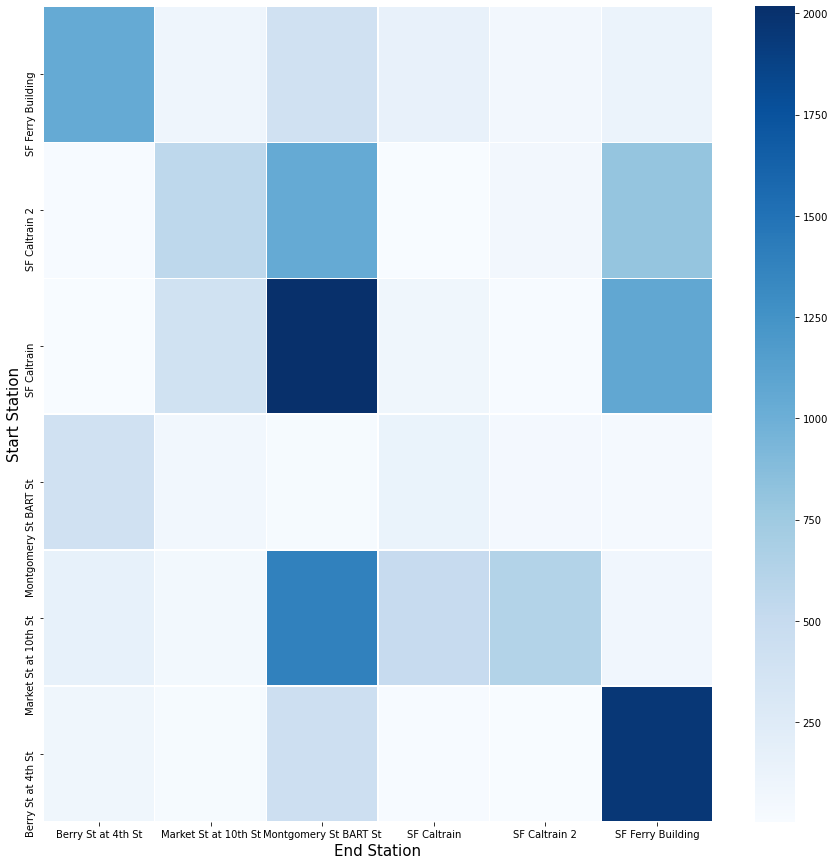

```python
df_bike_trips_most_used_stations = df_bike_trips[(df_bike_trips.start_station_name.isin(most_frequent_stations)) & (df_bike_trips.end_station_name.isin(most_frequent_stations))]
df_am = df_bike_trips_most_used_stations[(df_bike_trips_most_used_stations.hour_of_day >= 7) & (df_bike_trips_most_used_stations.hour_of_day <= 9)]
graph_stations_correlation(df_am, 'Heatmap of stations correlation bike rides - most used stations 7-9 am')
```

##### Conclusion:

- There are much more rides from **San Francisco Caltrain (Townsend St at 4th St)** to **Montgomery St BART Station (Market St at 2nd St)** from 7-9 am than the opposit.
- This means, we need to transport the bikes (by a truck or so) bake to **San Francisco Caltrain (Townsend St at 4th St)**

## Thank you

> **Generate Slideshow**: Once you're ready to generate your slideshow, use the `jupyter nbconvert` command to generate the HTML slide show. . From the terminal or command line, use the following expression.

```python
!jupyter nbconvert Part_II_slide_deck_template.ipynb --to slides --post serve --no-input --no-prompt
```

```
^C
```

> This should open a tab in your web browser where you can scroll through your presentation. Sub-slides can be accessed by pressing 'down' when viewing its parent slide. Make sure you remove all of the quote-formatted guide notes like this one before you finish your presentation! At last, you can stop the Kernel.